# Инструменты разработки

Кирилл Корняков  
Сентябрь 2013

# Введение

Опыт типичного разработчика сегодня

- **Host**: Windows, Linux, Mac OS X
- **Target OS**: Windows, [Linux, Mac OS X], Android, iOS
- **Target HW**: x86, ARM, GPU, [DSP]
- **Языки**: С/С++/Objective-C, C#, Java, Python, CUDA
- **IDE**: Borland Builder, MSVS, Eclipse, Qt Creator, Xcode

# Базовые принципы

1. Предпочитайте plain-text формат в качестве исходного
   - Храните исходники в VCS
   - Овладейте техникой обработки текста в совершенстве
2. Освойте командную строку, используйте ее по максимуму
   - Обработка текста
   - Автоматизация рутинных операций
3. Изучите Python и его популярные модули
   - NumPy, Matplotlib
   - XML, Excel, pdf, email

# Базовые принципы (2)

1. В деталях изучите устройство бинарных модулей
   - Последовательность шагов построения приложений (компиляция и линковка)
   - Инструменты анализа готовых файлов
2. Разрабатывайте так, чтобы вам не приходилось заниматься отладкой
   - Непрерывная интеграция (автоматическое тестирование)
   - Контроль качества кода (автоматический анализ и peer review)
3. Переиспользуйте сторонние инструменты, преимущественно open-source
   - Стремительное развитие проекта (Android)
   - Полная свобода настройки и переделки

# Цели курса

Познакомить с некоторыми *универсальными* инструментами и подходами,  
которые будут полезны при работе над любым проектом и на любой платформе.

**Хороший инструмент**

1. Не самый новый
2. Кросс-платформенный
3. Допускает автоматизацию
4. Быстрый
5. С открытым исходным кодом (желательно)

Мы постараемся сосредоточиться на "хороших" инструментах.  
И очень часто это будут консольные и веб-приложения =)

# Программа курса

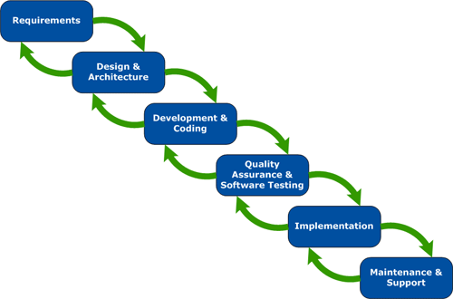

Software Development Lifecycle

# Программа курса

1. Личное мастерство
   - Работа с текстом
   - Автоматизация
2. Работа с кодом
   - Процесс построения
   - Анализ бинарных модулей
3. Качество кода
   - Содержание кода "в чистоте"
   - Тестирование и отладка
4. Коллективная разработка
   - Коммуникация
   - Управление задачами
   - Формирование сообщества

# Структура лекций

1. Первые 10 минут письменная самостоятельная работа
   - Рекомендуется посещать и не опаздывать
2. Основная часть, лекция
   - Рекомендуется вести конспект
3. Последние 5 минут объявление контрольных вопросов
   - Рекомендуется убедиться, что вопросы были разобраны

# Практические занятия

Необходимо разработать библиотеку на С++, которая:

1. Разрабатывается на GitHub
2. Решает простую прикладную задачу
3. Имеет документацию в Doxygen формате (или Sphinx)
4. Собирается при помощи CMake
5. Имеет модульные тесты на базе GoogleTest
6. Может будет иметь Java API в дополнение к С++ (а может и Python)

Каждый шаг засчитывается в момент попадания вашего кода в [центральный репозиторий](https://github.com/UNN-VMK-Software/devtools-course).

# Отчетность

- Наличие всех самостоятельных работ
- Наличие кода в **центральном** репозитории

При *своевременном* выполнении всех заданий - освобождение.

# Ресурсы

**Книги**

- Дейв Томас, Энди Хант "Программист-прагматик"
- Нил Форд "Продуктивный программист"
- Kernighan & Pike, The Practice of Programming, Addison-Wesley, 1999, ISBN 020161586X
- Стив Макконнелл "Совершенный код"

**Ссылки**

- https://help.github.com
- https://github.com/UNN-VMK-Software/devtools-course

# Спасибо за внимание!

Вопросы?